# Bayesian Modeling

## The p-value

Quantifying how far into the tails our observed count was.

```r
table(sim_singles)
```

```
## sim_singles
##   1   3   5   7   9  11
##   2  48 248 411 250  41
```

```r
table(sim_singles)[6]/1000
```

```
##    11
## 0.041
```

## Question

What is the best definition for our p-value in probability notation?

1. P(\(H_0\) is true | data) = 0.041
2. P(\(H_0\) is false | data) = 0.041
3. P(\(H_0\) is true) = 0.041
4. P(data | \(H_0\) is true) = 0.041
5. P(data) = 0.041

## Question

What is the best definition for our p-value in probability notation?

1. P(\(H_0\) is true | data) = 0.041
2. P(\(H_0\) is false | data) = 0.041
3. P(\(H_0\) is true) = 0.041
4. **P(data | \(H_0\) is true) = 0.041**
5. P(data) = 0.041

## The challenges with the classical method

The result of a hypothesis test is a probability of the form:

\[ P(\textrm{ data or more extreme } | \ H_0 \textrm{ true }) \]

while most people *think* they're getting

\[ P(\ H_0 \textrm{ true } | \textrm{ data }) \]

How can we go from the former to the latter?

## What we have

[figure not shown]

## What we want

[figure not shown]

## Bayesian Modeling

## Bayes Rule

\[P(A \ | \ B) = \frac{P(A \textrm{ and } B)}{P(B)} \]

\[P(A \ | \ B) = \frac{P(B \ | \ A) \ P(A)}{P(B)} \]

\[P(model \ | \ data) = \frac{P(data \ | \ model) \ P(model)}{P(data)} \]

What does it mean to think about \(P(model)\)?

Please draw your own subjective distributions for the following events.

1. The probability that Hilary will win the presidency.
2. The probability that, on a given night, the sun has gone super nova.
3. The total number of individual socks that you own.

## Prior distribution

A *prior distribution* is a probability distribution for a *parameter* that summarizes the information that you have before seeing the data.

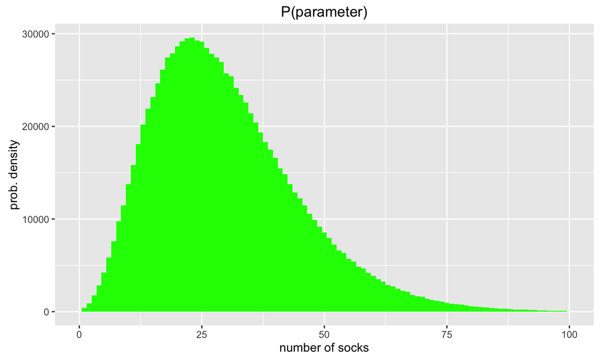

## Prior on proportion pairs

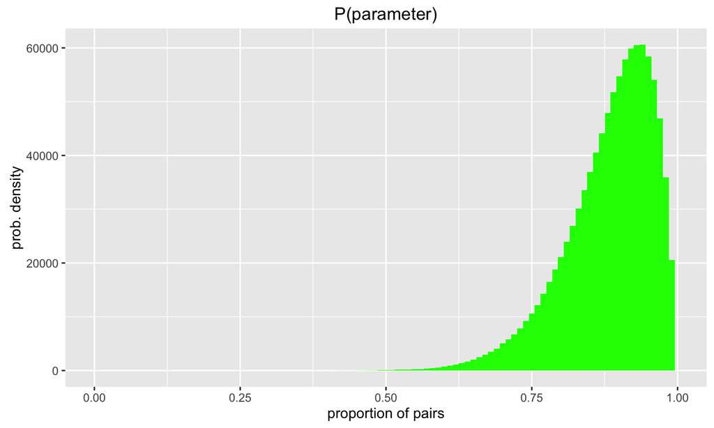

[figure not shown]

## Full simulation

```r
head(sock_sim)
```

```
##   unique pairs n_socks prop_pairs
## 1      3     4      16      0.970
## 2      7     2      33      0.914
## 3      9     1      51      0.929
## 4      1     4       9      0.955
## 5      9     1      45      0.851
## 6      9     1      21      0.726
```

```r
sock_sim %>%
  filter(unique == 11, pairs == 0) %>%
  head()
```

```
##   unique pairs n_socks prop_pairs
## 1     11     0      49      0.692
## 2     11     0      37      0.873
## 3     11     0      49      0.815
## 4     11     0      62      0.961
## 5     11     0      53      0.974
## 6     11     0      59      0.847
```

## Proportion of pairs

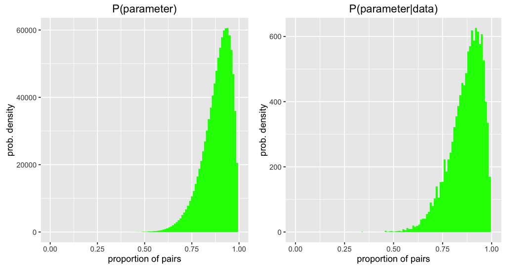

## Number of socks

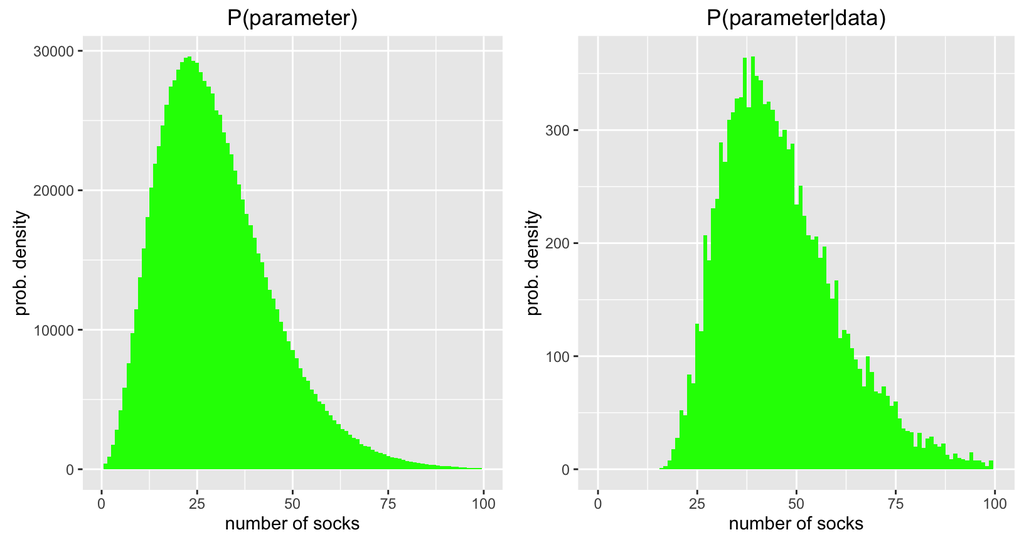

## Karl Broman's Socks

[figure not shown]

## The posterior distribution

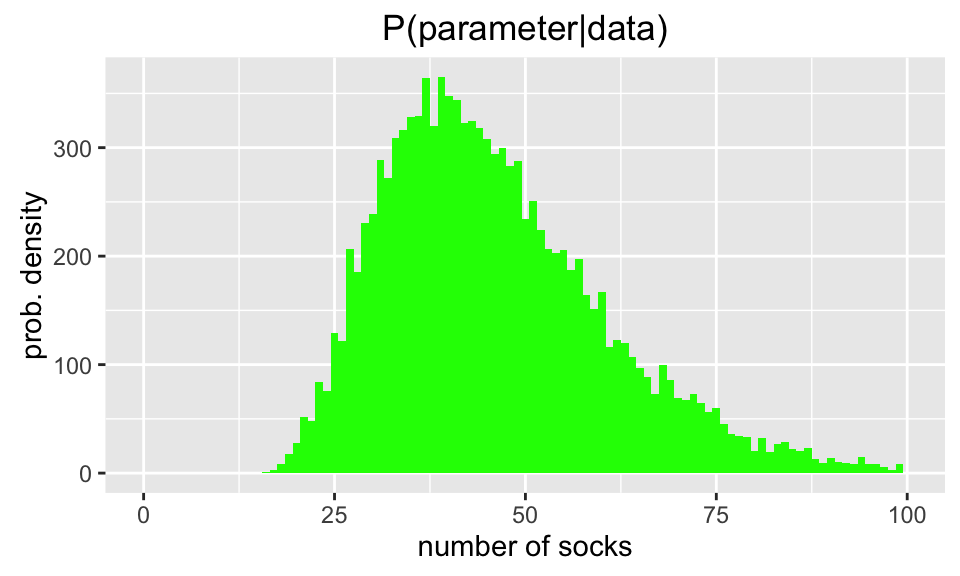

- Distribution of a parameter after conditioning on the data
- Synthesis of prior knowledge and observations (data)

### Question

What is your best guess for the number of socks that Karl has?

## Our best guess

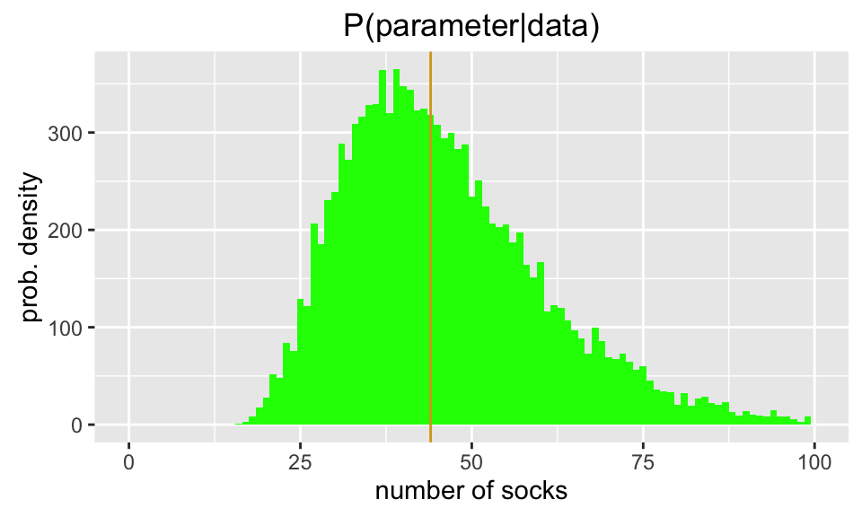

- The posterior median is 44 socks.

## Karl Broman's Socks

[figure not shown]

\[ 21 \times 2 + 3 = 45 \textrm{ socks} \]

## Summary

Bayesian methods . . .

- Require the subjective specification of your prior knowledge
- Provide a posterior distribution on the parameters
- Have strong intuition
- Are computationally expensive

[figure not shown]